# Machine learning

Week 8: additivity vs interactions, and ensembles

List our modeling assumptions and their respective methods

## Where we left off

| Assumption | Methods |
| --- | --- |
| Linearity | linear and logistic regression |
| Smoothness (Lipschitz) | $k$ nearest neighbors; also trees and networks |
| Additivity: one curve per input | additive models (a spline per input) |
| Limited wiggliness | penalized splines |
| Sparsity: few inputs matter | the lasso |
| Small coefficients | ridge regression |

### Week 8: additivity vs interactions, and ensembles

Part 1: fitting an additive model

Part 2: additivity vs interactions

Part 3: building a tree

Part 4: three model improvement strategies

### Part 1: fitting an additive model

## The movies data

```r
library(ggplot2movies)
mv <- movies |>
  filter(length <= 200, length > 10,
         year > 1918, votes >= 20)
```

IMDb films up to 2005, 33,287 after this selection ([data note](https://ml4ds.com/data/movies.html))

- **Target**: `rating`, average user rating, 1 to 10
- **Inputs**: `year`, `length` (minutes), seven genre flags
- Not used: `votes`, `r1` to `r10` (from the same ratings)

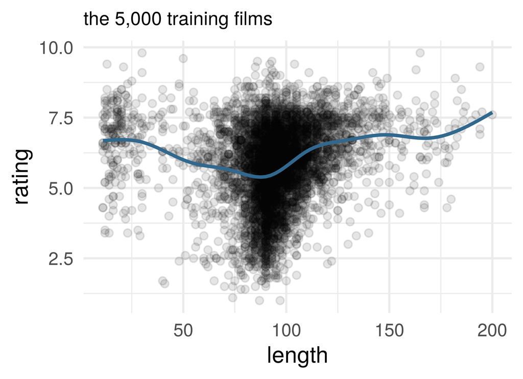

A random 10,000: 5,000 training, 2,000 tuning, 3,000 test

## Additive combination of non-linear predictors

```r
library(gam)
fit_gam <-
  gam(rating ~ s(length, df = 8) + s(year, df = 8) + Short, data = mv_train)
```

`s` is a smoothing spline with `df` fixed by us; `lo` would use local regression

```r
summary(fit_gam)$anova
```

```
Anova for Nonparametric Effects
                  Npar Df Npar F     Pr(F)
(Intercept)
s(length, df = 8)       7 19.535 < 2.2e-16 ***
s(year, df = 8)         7 38.841 < 2.2e-16 ***
Short
---
Signif. codes:  0 '***' 0.001 '**' 0.01 '*' 0.05 '.' 0.1 ' ' 1
```

No single slope per input: how do we interpret the fitted curves?

## Replace each linear coefficient with 2d plot

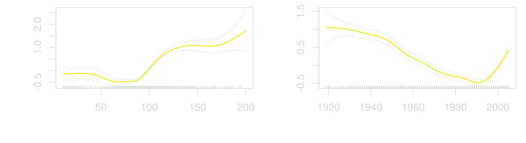

```r
par(mfrow = c(1, 2))
plot(fit_gam, se = TRUE, terms = c("s(length, df = 8)", "s(year, df = 8)"))
```

The cost of a non-free lunch: a sum of a fixed number of Lipschitz one-input curves (additivity, plus design conditions) has the one-input rate, $n^{-2/3}$.

## Fitting several curves

Could we fit this model one curve at a time?

## Backfitting algorithm

Model: $\hat f(x_1, \ldots, x_p) = \hat\beta_0 + \hat f_1(x_1) + \cdots + \hat f_p(x_p)$. Columns $\mathbf x_1, \ldots, \mathbf x_p$; $\hat f_k(\mathbf x_k)$ is the vector of fitted values of curve $k$

1. Initialize: $\hat\beta_0 = \bar y$, and $\hat f_j^{(0)} = 0$ for every $j$
2. For iteration $t = 1, 2, \ldots$:
   - for $j = 1, \ldots, p$:
     - partial residual $\mathbf r_j^{(t)} = \mathbf y - \hat\beta_0 - \sum_{k < j} \hat f_k^{(t)}(\mathbf x_k) - \sum_{k > j} \hat f_k^{(t-1)}(\mathbf x_k)$
     - $\hat f_j^{(t)}$: a one-input smoother (e.g. a spline) of $\mathbf r_j^{(t)}$ on $\mathbf x_j$, centered to mean zero
   - stop when iteration $t$ barely changes the fitted values

## Backfitting and partialling out

Two centered inputs, and a line for each component: $\hat f_j(x) = \hat\beta_j x$. Start at $\hat\beta_2^{(0)} = 0$. Iteration $t$ fits each slope to its partial residual:
$$\hat\beta_1^{(t)} = \frac{\mathbf x_1^T\big(\mathbf y - \hat\beta_2^{(t-1)} \mathbf x_2\big)}{\mathbf x_1^T \mathbf x_1}, \qquad
\hat\beta_2^{(t)} = \frac{\mathbf x_2^T\big(\mathbf y - \hat\beta_1^{(t)} \mathbf x_1\big)}{\mathbf x_2^T \mathbf x_2}$$

The slopes stop changing only where both hold: $\mathbf x_j^T(\mathbf y - \hat\beta_1 \mathbf x_1 - \hat\beta_2 \mathbf x_2) = 0$ for $j = 1, 2$. These are the normal equations: the fixed point is least squares

Partialling-out theorem: the coefficient on $\mathbf x_2$ is $\tilde{\mathbf x}_2^T \mathbf y / \tilde{\mathbf x}_2^T \tilde{\mathbf x}_2$, the slope on what is left of $\mathbf x_2$ after $\mathbf x_1$ has explained what it can.

Backfitting does this with smooth curves instead of lines

## Backfitting on the films

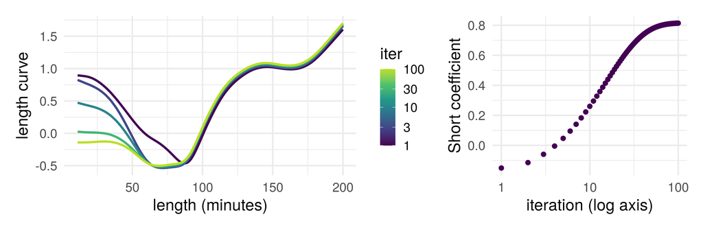

Length, year and Short on the training films, starting from zero. Length and Short are closely related: each iteration moves a little more of the shorts’ higher ratings from the length curve to the Short coefficient, which settles after about 70 iterations

## Backfitting, more generally

**Any number of inputs.** With one coefficient per input, each update minimizes the RSS over that coefficient with the others held fixed: **coordinate descent** (Gauss–Seidel, in numerical linear algebra). A spline gives each input a block of coefficients, updated together: **block coordinate descent**. Fast for unrelated inputs, slow for strongly related ones

**Gram–Schmidt** residualizes each input (predictor) on the ones before it, once. Backfitting leaves the inputs alone and residualizes $\mathbf y$ iteratively

**Partialling out with flexible fits.** Residualize both $\mathbf y$ and $\mathbf x_j$ on the other inputs, with any regression method, then regress residual on residual: **double machine learning**, later in the course

### Part 2: additivity vs interactions

## Partial dependence plots for a GAM

These univariate plots for GAMs are called **partial dependence plots** (PDPs), each up to a constant: for an additive fit, the partial dependence on $x_j$ is $\hat f_j$ plus a constant. They show how the GAM depends on each feature: a simple one-dimensional dependence, because of the additivity assumption

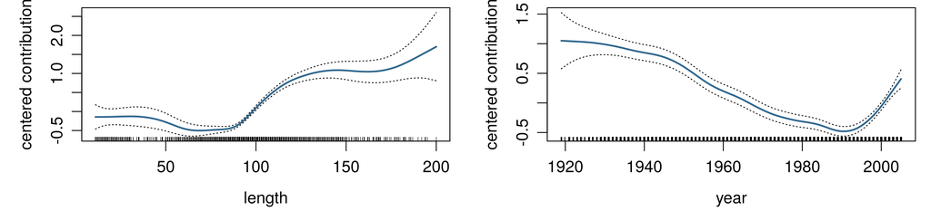

But what if additivity is wrong?

## All models are wrong

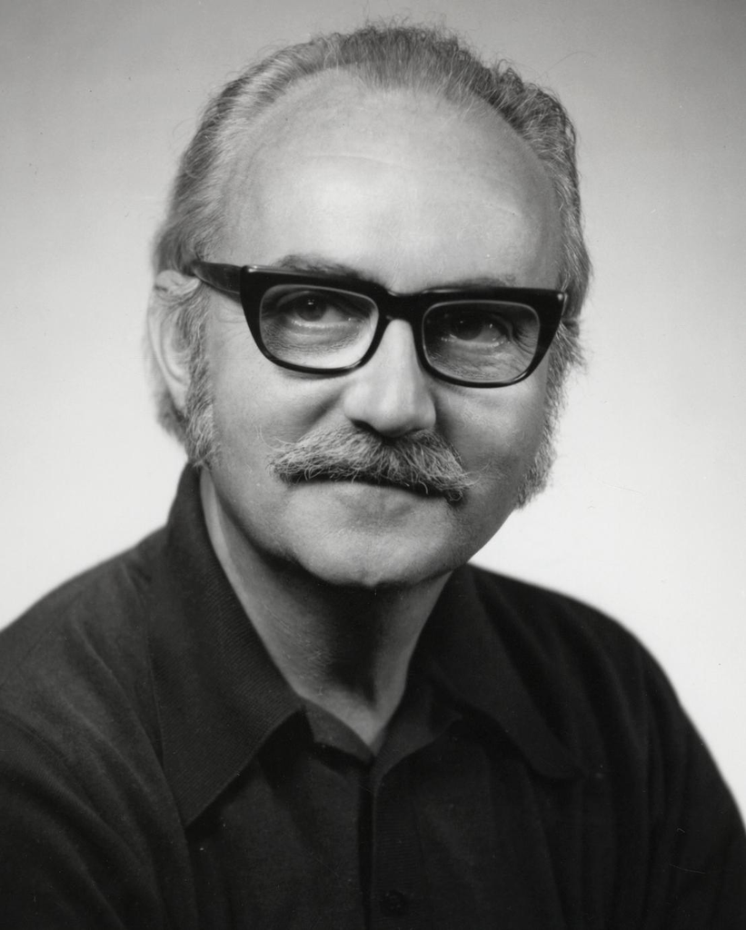

[George Box, ca. 1974](https://search.library.wisc.edu/digital/AVKGAZNVOXF4YF9B). UW–Madison Archives

[All models are wrong, but some are useful](https://en.wikipedia.org/wiki/All_models_are_wrong)

> Since all models are wrong the scientist must be alert to what is **importantly wrong**. It is inappropriate to be concerned about mice when there are tigers abroad.

Box (1976), emphasis added

> Remember that all models are wrong; the practical question is how wrong do they have to be to not be useful.

Box and Draper (1987)

## Can additivity/GAMs be *importantly wrong*?

Interpretation: think carefully about **calculus** and **causality** (causality: briefly, after the interactions). To simplify let’s consider the identity link function (rather than e.g. logistic regression, those cases are more complicated)

#### Calculus

Does the CEF really decompose into additive terms? Is this approximation good:

$$\frac{\partial}{\partial x_j} \mathbb E[Y | \mathbf X] \approx f_j'(x_j)$$
Or does the relationship between the average of $Y$ and $x_j$ vary depending on the value of another predictor $x_k$?

## Interactions in the movies data

If the slope in length changes with year, the derivative of $\mathbb E[\text{rating} \mid \text{length}, \text{year}]$ in length depends on year too, and an additive model is misspecified. Non-shorts, by decade:

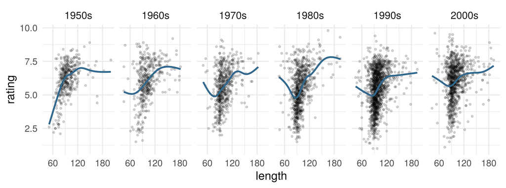

## True model non-additive; GAM is wrong

```r
f1 <- function(x) x^2
f2 <- function(x) cos(pi * x / 2)
df_int <- tibble(x1 = runif(2000, -1, 1), x2 = runif(2000, -4, 4)) |>
  mutate(y = f1(x1) * f2(x2) + rnorm(2000))
fit_gam_wrong <- gam(y ~ s(x1) + s(x2), data = df_int)
```

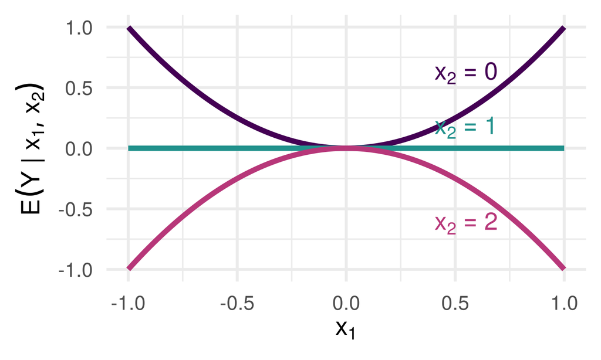

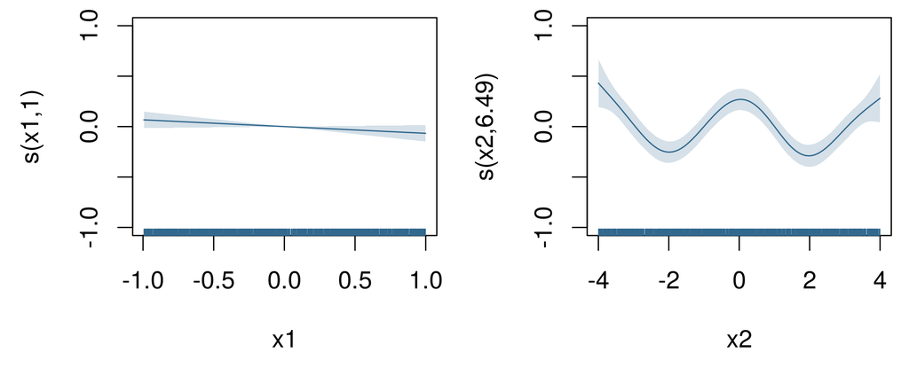

The fitted component for $x_1$ is nearly flat: the parabolas cancel when averaged over $x_2$. Additivity assumption is now (importantly) wrong

## Causality: what are we “controlling for”?

*Louisiana v. Callais*, US Supreme Court, 29 April 2026, 6 to 3: evidence of racially polarized voting must come from “an analysis that controls for party affiliation”

- The majority’s reasoning: the divide may be partisan rather than racial, so race counts only where it survives holding party fixed
- Critics argue that this misuses statistics: party is partly a **consequence** of race, so holding it fixed removes part of what is to be measured (Morris 2026)
- After the decision, several Southern states redrew their congressional maps before the November 2026 midterm elections

What would a GAM of vote share on race and party show?

## Causality: what partial dependence holds fixed

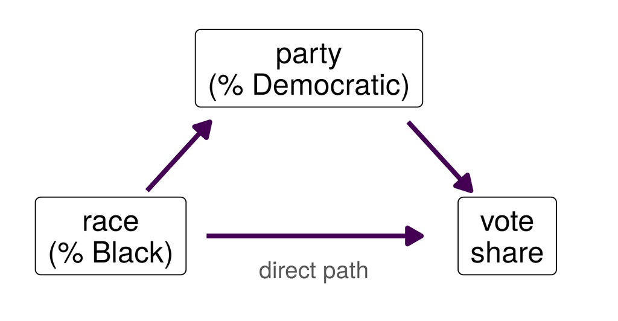

Simulated counties, an additive CEF, a GAM that fits it. Each partial dependence plot holds the other input fixed: the **direct** path only. Race acts mostly through party, a **mediator**

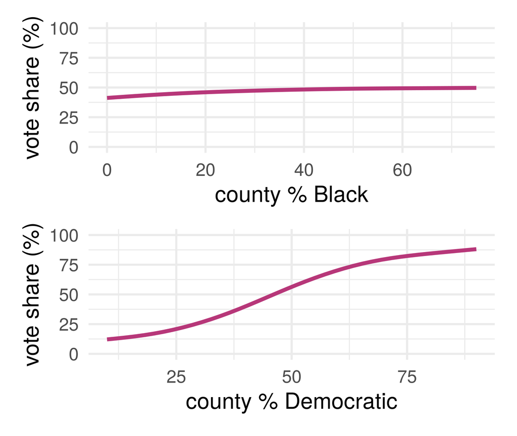

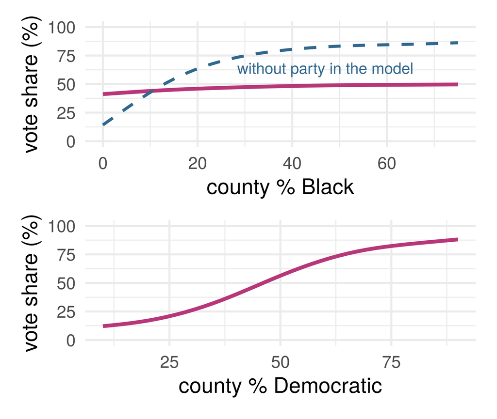

## Recap: the causal example

The GAM fits correctly, the plot interprets the GAM correctly, but the plot answers the wrong (uninteresting) causal question

Adjustment theorem: adjust for common causes of $T$ and $Y$, and for **no consequence** of $T$

### Part 3: building a tree

## The Star Wars films

| Episode | Film | Year | Length (minutes) | Rating |
| --- | --- | --- | --- | --- |
| IV | Star Wars | 1977 | 125 | 8.8 |
| V | The Empire Strikes Back | 1980 | 129 | 8.8 |
| VI | Return of the Jedi | 1983 | 135 | 8.1 |
| I | The Phantom Menace | 1999 | 133 | 6.4 |
| II | Attack of the Clones | 2002 | 120 | 7.0 |

Ratings: IMDb users’ averages, up to 2005

We’ll walk through growing and pruning a tree on this small subset of the data

## RSS for each possible split

| Split | Yes | No | Mean, yes | Mean, no | RSS |
| --- | --- | --- | --- | --- | --- |
| year < 1978.5 | IV | V, VI, I, II | 8.80 | 7.58 | 3.49 |
| year < 1981.5 | IV, V | VI, I, II | 8.80 | 7.17 | 1.49 |
| **year < 1991** | **IV, V, VI** | **I, II** | **8.57** | **6.70** | **0.51** |
| year < 2000.5 | IV, V, VI, I | II | 8.03 | 7.00 | 3.85 |
| length < 122.5 | II | IV, V, VI, I | 7.00 | 8.03 | 3.85 |
| length < 127 | IV, II | V, VI, I | 7.90 | 7.77 | 4.67 |
| length < 131 | IV, V, II | VI, I | 8.20 | 7.25 | 3.61 |
| length < 134 | IV, V, I, II | VI | 7.75 | 8.10 | 4.59 |

No split: every film predicted by the mean, 7.82, RSS 4.69. Each side of a split is a **leaf**; the search then **recurses** into each leaf

## Recursion: RSS for each split inside each leaf

**Yes to year < 1991: IV, V, VI** (RSS 0.33)

| Split | Yes | No | Mean, yes | Mean, no | RSS |
| --- | --- | --- | --- | --- | --- |
| year < 1978.5 | IV | V, VI | 8.80 | 8.45 | 0.25 |
| **year < 1981.5** | **IV, V** | **VI** | **8.80** | **8.10** | **0.00** |
| length < 127 | IV | V, VI | 8.80 | 8.45 | 0.25 |
| length < 132 | IV, V | VI | 8.80 | 8.10 | 0.00 |

**No: I, II** (RSS 0.18)

| Split | Yes | No | Mean, yes | Mean, no | RSS |
| --- | --- | --- | --- | --- | --- |
| **year < 2000.5** | **I** | **II** | **6.40** | **7.00** | **0.00** |
| length < 126.5 | II | I | 7.00 | 6.40 | 0.00 |

Ties go to the first input, year. Every new leaf holds films of one rating: RSS 0, and growing stops

## The grown tree

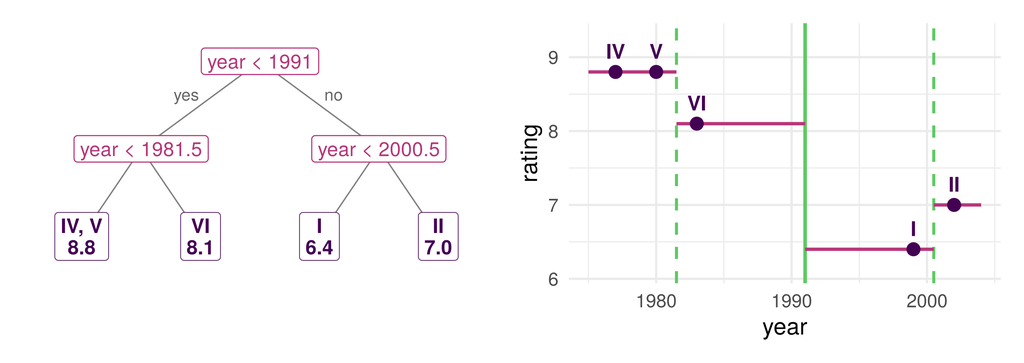

4 leaves, each holding films of one rating: a training RSS of 0. Grown until it cannot split, a tree memorizes its training data

## Growing a tree

- **Recursive**: split the data by the most discriminating single-variable question; then do the same inside each leaf, and so on
- **Greedy**: each split is the best *now*. A weak split that would enable a strong one below it can be missed, so stopping early is risky: grow a large tree, then prune (next slide)
- **When to stop**: a leaf too small to split (rpart’s `minsplit`), or no split that improves the fit enough (`cp`)
- Grown until no leaf can split, a tree is like 1-nearest neighbors: on the training films, year and length alone give 2,670 leaves

$k$ nearest neighbors average the $k$ training points closest to $x_0$; a tree averages those in $x_0$’s leaf, a neighborhood chosen by subsets of features

## Pruning

For each $\alpha \geq 0$, the sub-tree minimizing $\text{RSS} + \alpha \times (\text{number of leaves})$. The Star Wars tree, as $\alpha$ increases from 0:

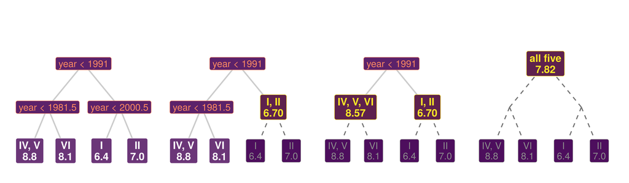

Sequence of trees; tuning knob $\alpha$ chosen by cross-validation or held-out data

## Choosing $\alpha$ on the films

A tree on all nine inputs, grown to 272 leaves, pruned back along its sequence. Training error falls with every leaf; tuning error is lowest at 56 leaves

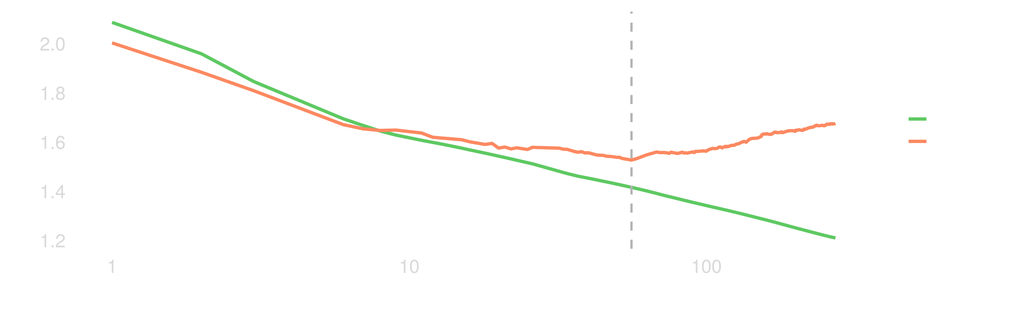

## Trees and missing inputs

The films’ `budget` is missing for 87%: a film with no budget cannot answer “budget < c?”

- **Missingness as information**: a split also chooses which side the films with no budget go to, like its cutoff, to lower the RSS (xgboost’s *default direction*); or a budget missing indicator that the tree can split on
- **Missingness as a nuisance**: rpart’s *surrogate splits*, backup questions on other inputs that send the training films the same way; a film missing the split’s input follows the best backup it can answer
- Informative here: budgets were recorded mostly for widely rated films (median 1,238 votes, against 71). Potentially useful for prediction

## A downside of trees: variance

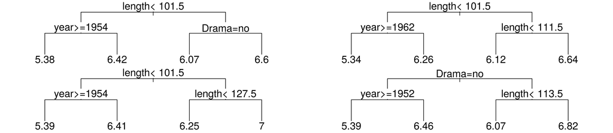

Depth 2, each on a random half of the training films. *Star Wars: Episode I - The Phantom Menace* (rated 6.4): predicted 6.07, 6.64, 7.00, 5.39

Same method, random halves of the same films, four different models. What should we do?

## Part 4: three model improvement strategies

Sacrifice simplicity/interpretability for prediction accuracy

#### **Bagging***: bootstrap aggregating

- Resample training data, average resulting models

#### **Random forest**

- Randomly drop predictors at each split

#### **Boosting***

- Successively add simple models to improve the aggregate

* Can be used with other models too, not just trees

## Bagging: bootstrap aggregating

**Problem**: a single tree model can have high variance (like many non-smooth or non-regularized models)

1. **Bootstrap**: for each $b = 1, \ldots, B$ resamples (with replacement) of the training data, fit $\hat f^b$ on bootstrap sample $b$
2. **Aggregate**: combine the $B$ models, using majority vote for classification or mean for regression

$$\hat f_\text{bag} = \frac{1}{B} \sum_{b=1}^B \hat f^b$$

(“Smoothing” useful for high-variance models)

## Averaging $B$ trees

Average $B$ trees’ predictions at one input $x$ (variance over the draw of the training data, and of the resampling)

What is the variance of their average if the $B$ trees are

- copies of the *same* tree, with variance $\tau^2$?
- independent, each with variance $\tau^2$?
- each with variance $\tau^2$, every pair with correlation $\rho$?

## Recall: variance of a sum

For random variables $V_1, \ldots, V_n$ and constants $a_1, \ldots, a_n$, every variance plus every covariance:
$$\mathrm{Var}\Big(\sum_{i=1}^n a_i V_i\Big) = \sum_{i=1}^n a_i^2\, \mathrm{Var}(V_i) + \underbrace{\sum_{i=1}^n \sum_{j \neq i} a_i a_j\, \mathrm{Cov}(V_i, V_j)}_{n(n-1) \text{ terms; } \binom{n}{2} \text{ distinct}}$$

## Correlated-average variance

With $n = B$ and every $a_i = 1$: $B$ terms $\tau^2$ and $B(B - 1)$ terms $\rho\tau^2$, $\;\mathrm{Var}\big(\sum_{b} V_b\big) = B\tau^2 + B(B - 1)\rho\tau^2$

**Correlated-average variance.** $V_1, \ldots, V_B$, each with variance $\tau^2$, every pair with correlation $\rho$:
$$\mathrm{Var}\Big(\frac1B \sum_{b=1}^B V_b\Big) = \rho\,\tau^2 + (1 - \rho)\,\frac{\tau^2}{B}$$

**Proof**: divide by $B^2$ and regroup, $\frac{\tau^2}{B} + \frac{B - 1}{B}\rho\tau^2 = \rho\tau^2 + (1 - \rho)\frac{\tau^2}{B}$. Bagging shrinks the second term; $\rho\tau^2$ stays, since bootstrap trees grown from one sample are alike

## Random forest: dropping predictors

Suppose $B$ is large, say 300. Which term of the correlated-average variance is left, and how could we make it smaller?

**Problem**: aggregation does not increase information if the aggregates are highly correlated, e.g. averaging 1000 trees but each one uses the same small set of predictor variables

1. **Drop** predictors randomly, at every split

   e.g. each split chooses among a random $\sqrt{p}$ of the $p$ predictors
2. **Aggregate** models which are now (typically) less correlated, achieving greater variance reduction

## Out-of-bag predictions

- Each bootstrap sample contains some subset of the training data
- Roughly $1/e \approx 0.37$ portion of the training samples will be left out of each bootstrap sample
- Can use these to estimate test error (e.g. instead of $K$-fold cross-validation)

Software implementations may do this automatically

| A forest on the films, 300 trees | MSE |
| --- | --- |
| training films, every tree | 1.19 |
| training films, out-of-bag trees only | 1.50 |
| tuning films | 1.49 |
| tuning films, predicting the training mean | 2.00 |

## Adding trees

A forest grows its trees separately and averages them. Now grow them one after another and add them up: after $b$ trees the fit is $\hat f^{(b)}$, the sum so far

We may add one small tree to $\hat f^{(b)}$. What should it predict?

The residual from the existing fit: $y - \hat f^{(b)}(x)$

## Boosting: iterated fitting on residuals

**Idea**: train models sequentially, decreasing residuals by a small amount each time. Each model contributes something different

Can use “weak learners” (e.g. trees with one split, “stumps”) to grow an ensemble model gradually fitting closer to the training data

#### Relationship with gradient descent

**Gradient descent**: small step in direction of negative gradient

**Boosting**: small step in direction of *weak learner approximating the negative gradient*

Instead of taking an unrestricted gradient step, we reduce the loss by taking a small step in the direction of a weak learner: a simple, low-cost model

Optional additional reading: [ESL](https://hastie.su.domains/ElemStatLearn/) sections 10.10–10.12 (gradient boosting, tree size, regularization)

## Boosting as approximate gradient descent

The training loss depends on a model only through its $n$ fitted values $\mathbf f = (f_1, \ldots, f_n)$, $f_i = f(x_i)$: a function of $n$ numbers
$$L(\mathbf f) = \sum_{i=1}^n \tfrac12 (y_i - f_i)^2, \qquad -\frac{\partial L}{\partial f_i} = y_i - f_i$$
The negative gradient is the residual vector

A gradient step, $\mathbf f^{(b)} = \mathbf f^{(b-1)} + \gamma\,(\mathbf y - \mathbf f^{(b-1)})$, changes only those $n$ values. Boosting trees fits a small tree approximating the negative gradient (the residuals) and steps along it, with **learning rate** $\gamma$:
$$\hat f^{(0)} = \bar y, \qquad \hat f^{(b)} = \hat f^{(b-1)} + \gamma\, \hat t_b, \qquad \hat t_b \text{ a small tree fitted to } y_i - \hat f^{(b-1)}(x_i)$$

## Boosting in practice

#### More tuning parameters

Number of trees/steps $B$, complexity of each tree/model $d$, regularization/learning rate $\gamma$. **Warning**: can now overfit with large $B$ (unlike bagging/r.f.)

Software may choose them automatically. *No guarantee it’s reasonable!*

#### Bagging and boosting

Bagging and forests start with large trees, which have high variance individually, and average them to lower the variance. Boosting starts with weak learners like tree stumps, which have high bias individually, and fits iteratively on residuals to lower the bias

## Iterations and learning rate

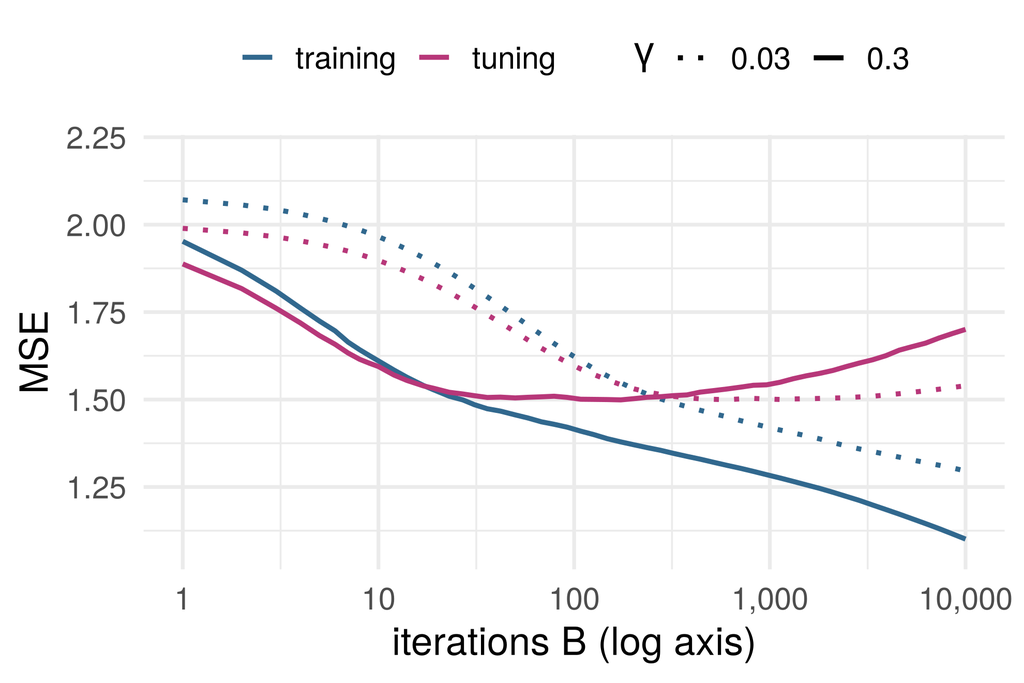

**Iterations $B$.** Training error keeps falling; tuning error turns. Stopping there is early stopping, as for gradient descent

**Learning rate $\gamma$.** Smaller steps

**Depth.** How many inputs one tree can combine (next)

## Tree depth and interactions

Can a tree with one split fit $f(x_1, x_2) = x_1 x_2$ well? Hint: assume the inputs are independent, both $\mathrm{Unif}[-1, 1]$

How many splits would we want for $f(x_1, \ldots, x_p) = x_1 \cdots x_p$?

A stump asks one question, so a sum of stumps is a sum of one-input functions: an **additive** model. Depth $d$: interactions of up to $d$ inputs

A boosted model is additive in trees, not in the predictors

## We’re in dangerous territory

- Less interpretable methods/models
- Many tuning parameters
- Increasingly sophisticated software with many defaults and/or automatically optimized tuning parameters

But consider, [Alfred North Whitehead](https://www.gutenberg.org/ebooks/41568) wrote (1911; emphasis added):

> It is a profoundly erroneous truism, repeated by all copy-books and by eminent people when they are making speeches, that we should cultivate the habit of thinking of what we are doing. The precise opposite is the case. **Civilization advances by extending the number of important operations which we can perform without thinking about them**.

## Conclusion

#### Additive models

One curve per input, each fitted to what the others leave: partialling out, one input at a time

#### Additivity vs interactions

A plot of one input at a time works most naturally for additive models, and can be importantly wrong when the truth has interactions

#### Trees and ensembles

Greedy questions, pruned by validation. Bagging and forests average trees to lower variance; boosting adds small trees, gradient descent on the fitted values

## References

- Box, G. E. P. (1976). Science and statistics. *Journal of the American Statistical Association* 71(356), 791–799. [doi:10.1080/01621459.1976.10480949](https://doi.org/10.1080/01621459.1976.10480949). The quotation is in section 2.4.
- Box, G. E. P. and Draper, N. R. (1987). *Empirical Model-Building and Response Surfaces*. New York: Wiley.
- Breiman, L., Friedman, J. H., Olshen, R. A. and Stone, C. J. (1984). *Classification and Regression Trees*. Belmont, CA: Wadsworth.
- Chen, T. and Guestrin, C. (2016). XGBoost: a scalable tree boosting system. *Proceedings of the 22nd ACM SIGKDD International Conference on Knowledge Discovery and Data Mining*, 785–794. [doi:10.1145/2939672.2939785](https://doi.org/10.1145/2939672.2939785)
- Josse, J., Chen, J. M., Prost, N., Varoquaux, G. and Scornet, E. (2024). On the consistency of supervised learning with missing values. *Statistical Papers* 65(9), 5447–5479. [doi:10.1007/s00362-024-01550-4](https://doi.org/10.1007/s00362-024-01550-4)
- *Louisiana v. Callais*, 608 U.S. 85 (2026), No. 24-109, decided 29 April 2026. [Opinion (preliminary print)](https://www.supremecourt.gov/opinions/25pdf/608us1r29_n648.pdf). The quotation is in the syllabus, at 88.
- Morris, G. E. (2026). The simple statistical error Republican Supreme Court justices used to gut the VRA. *Strength In Numbers*, 8 May 2026. [Link](https://www.gelliottmorris.com/p/2026-05-08-simple-math-error-scotus-callais-vra)
- Twala, B. E. T. H., Jones, M. C. and Hand, D. J. (2008). Good methods for coping with missing data in decision trees. *Pattern Recognition Letters* 29(7), 950–956. [doi:10.1016/j.patrec.2008.01.010](https://doi.org/10.1016/j.patrec.2008.01.010)
- Whitehead, A. N. (1911). *An Introduction to Mathematics*. London: Williams and Norgate. [Project Gutenberg](https://www.gutenberg.org/ebooks/41568). The quotation is in chapter 5, “The Symbolism of Mathematics”.